# Projekt eksploracja

Szymon Dufek

2023-06-02

# Wstęp

Celem projektu jest jak najdokładniejsza klasyfikacja osób chorujących na cukrzycę. Dane zawierają klasyczne parametry dzięki którym lekarz jest w stanie ocenić, czy pacjent jest chory. W śród nich znajdują się osóby które nie chorują na cukrzycę. Dane pochodzą ze strony kaggle ze zbioru [(link)](https://www.kaggle.com/datasets/iammustafatz/diabetes-prediction-dataset).

| Miara | Opis |
| --- | --- |
| Płeć | Płeć pacjenta - występują 3 poziomy: Mężczyzna, Kobieta, Inny. |
| Wiek | Wiek pacjenta |
| Nadciśnienie | Informacja, czy pacjent ma problemy z nadciśnieniem, gdzie 1 oznacza chorego pacjenta a 0 zdrowego. |
| Choroba serca | Informacja, czy pacjent ma inne choroby związane z pracą serca. |
| Czy pali | Informacja, czy pacjent w przeszłości palił wyroby tytoniowe. |
| BMI | Body Mass Index - współczynnik powstały przez podzielenie masy ciała podanej w kilogramach przez kwadrat wysokości podanej w metrach. |
| Wskaźnik HbA1c | Hemoglobina glikowana, miara pozwalająca ocenić średni poziom cukru we krwi z ostanich 2-3 miesięcy u pacjenta. |
| Poziom glukozy | Poziom glukozy we krwi w czasie wykonywania badnia. |
| Cukrzyca | Czy pacjent choruje na cukrzycę, gdzie 1 oznacza chorego pacjenta a 0 zdrowego. |

# Podstawowe statystki zmiennych liczbowych

|  | age | bmi | HbA1c_level | blood_glucose_level |
| --- | --- | --- | --- | --- |
| Min. | 0.08 | 10.01 | 3.50 | 80.00 |
| 1st Qu. | 24.00 | 23.63 | 4.80 | 100.00 |
| Median | 43.00 | 27.32 | 5.80 | 140.00 |
| Mean | 41.89 | 27.32 | 5.53 | 138.06 |
| 3rd Qu. | 60.00 | 29.58 | 6.20 | 159.00 |
| Max. | 80.00 | 95.69 | 9.00 | 300.00 |
| Sd | 22.52 | 6.64 | 1.07 | 40.71 |

# Płeć

## Liczebność

| gender | n |
| --- | --- |
| Female | 58552 |
| Male | 41430 |
| Other | 18 |

## Wykres kołowy liczby badanych ze względu na płeć

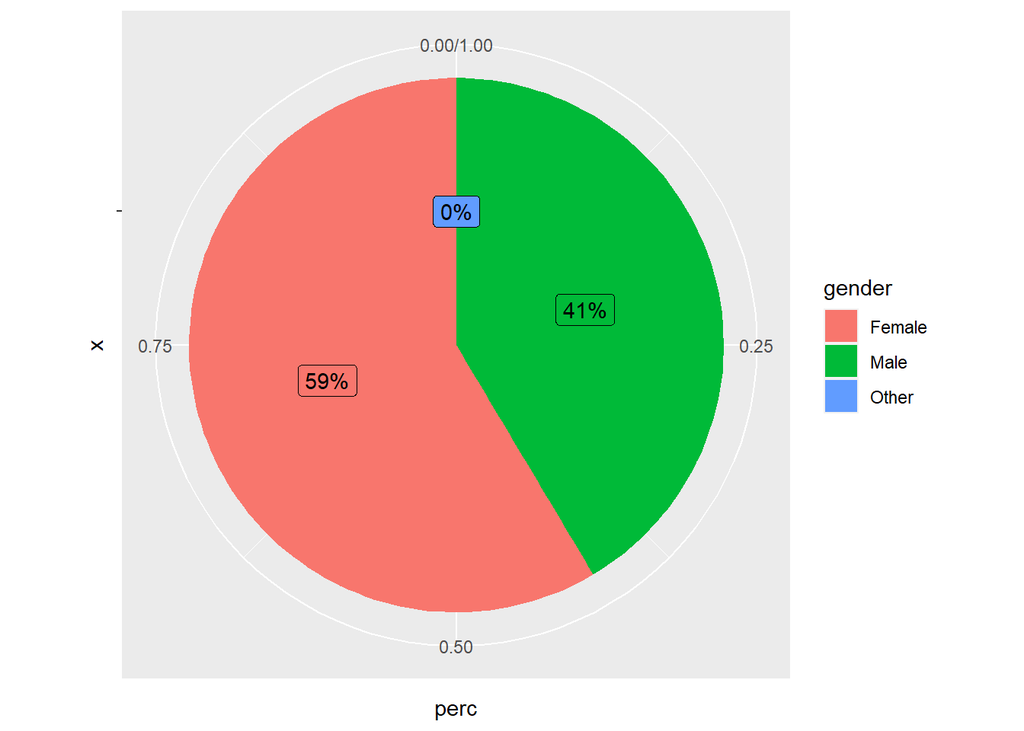

# Wiek

## Wykres histogram z rozkładem gęstości prawdopodobieństwa zmiennej wiek

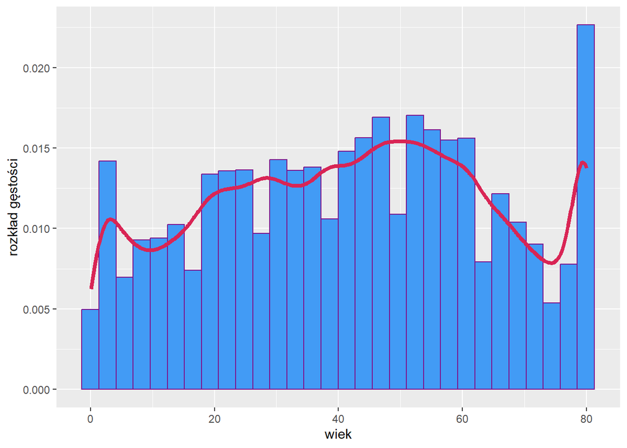

# Nadciśnienie

## Liczebność

| hypertension | n |
| --- | --- |
| 0 | 92515 |
| 1 | 7485 |

## Wykres kołowy liczby badanych ze względu na to czy pacjent ma problemy z nadciśnieniem

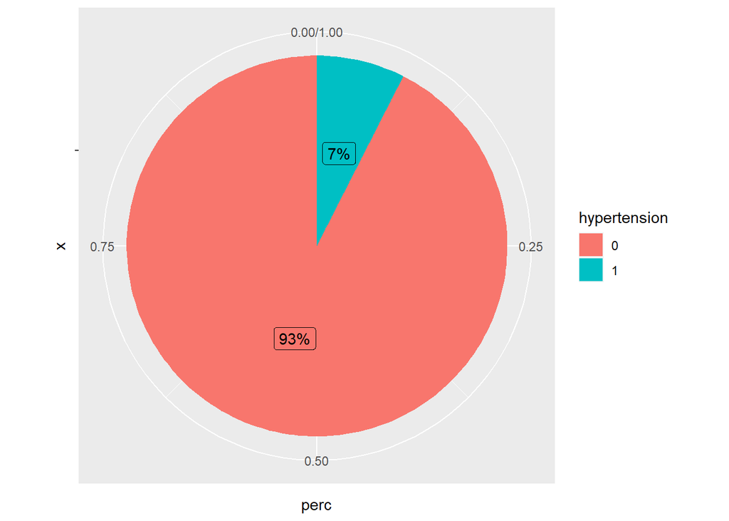

# Choroby serca

## Liczebność

| heart_disease | n |
| --- | --- |
| 0 | 96058 |
| 1 | 3942 |

## Wykres kołowy liczby badanych ze względu na to czy zmagali się z chorobami serca

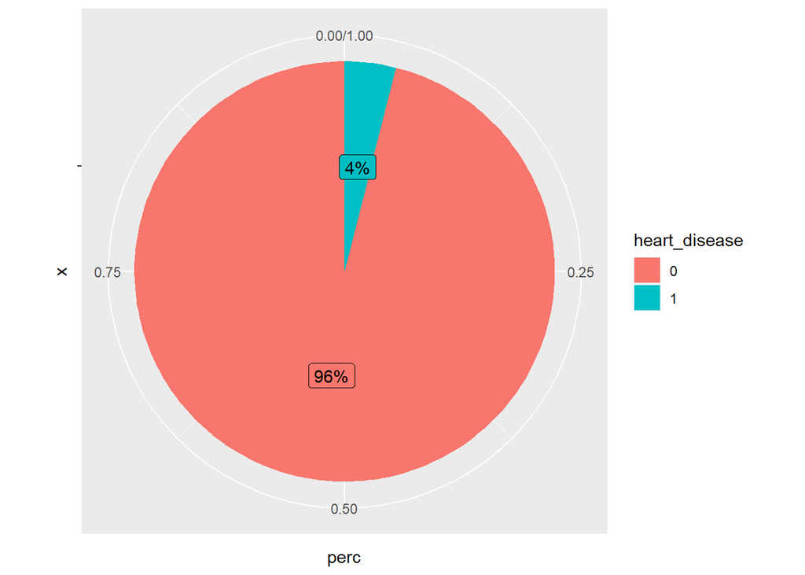

# Historia palenia

## Liczebność

| smoking_history | n |
| --- | --- |
| current | 9286 |
| ever | 4004 |
| former | 9352 |
| never | 35095 |
| No Info | 35816 |
| not current | 6447 |

## Wykres kołowy liczby badanych ze względu na to czy palili

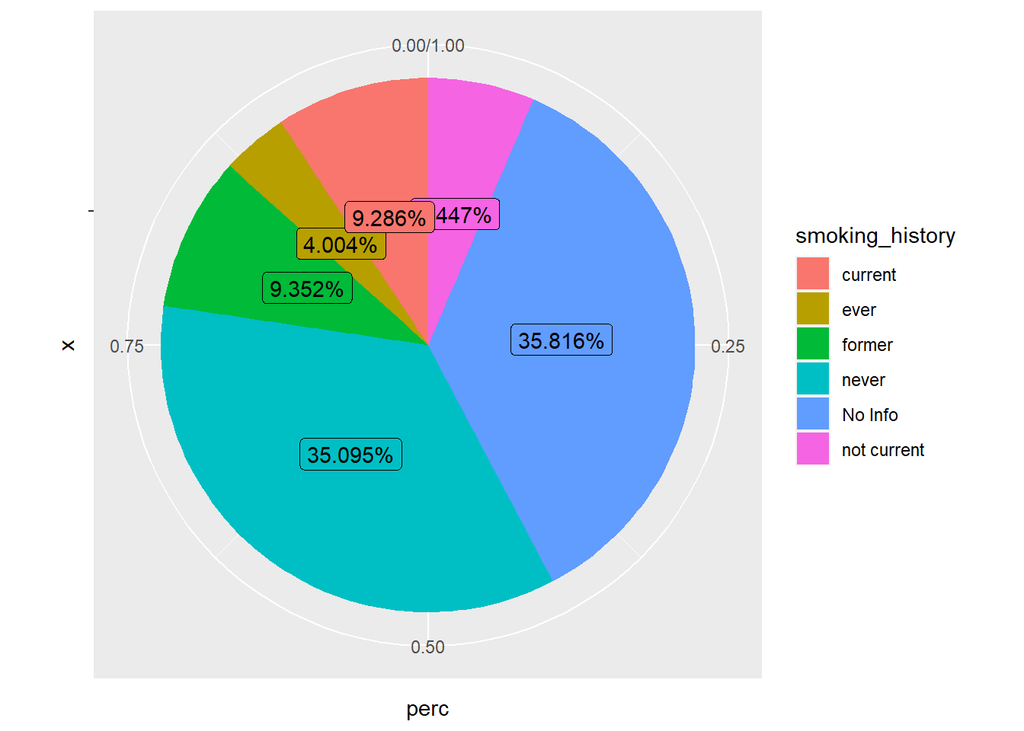

# BMI

## Wykres histogram z rozkładem gęstości prawdopodobieństwa zmiennej BMI

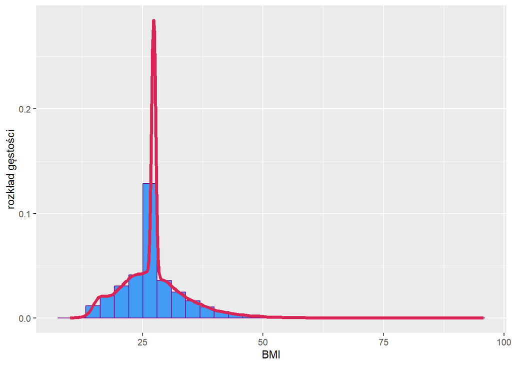

# Wskaźnik HbA1c

## Wykres histogram z rozkładem gęstości prawdopodobieństwa wskaźnika HbA1c

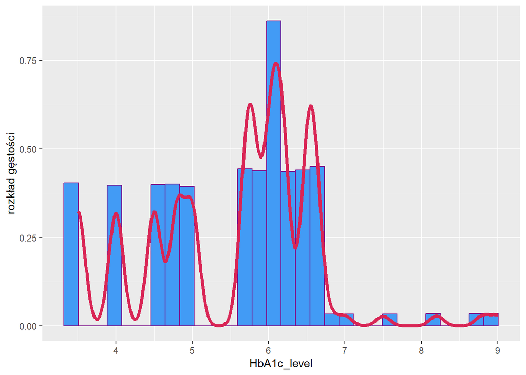

# Poziom glukozy we krwi

## Wykres histogram z rozkładem gęstości prawdopodobieństwa poziomów glukozy we krwi

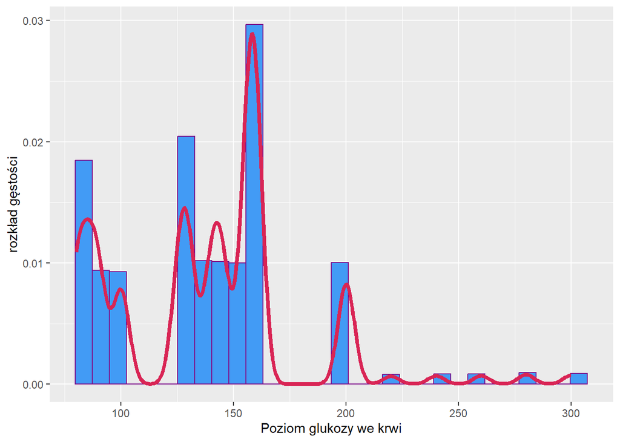

# Cukrzyca

## Liczebność

| diabetes | n |
| --- | --- |
| 0 | 91500 |
| 1 | 8500 |

## Wykres kołowy liczby badanych ze względu na to czy mają cukrzyce

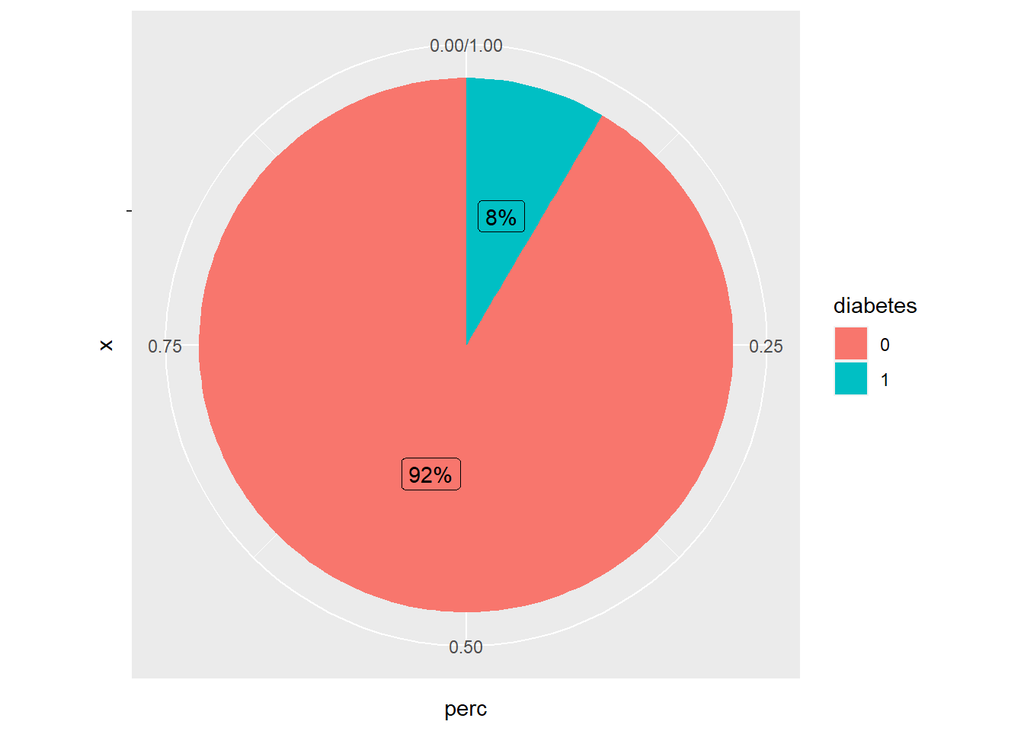

# Podział zbioru

Zbiór podzieliliśmy na uczący i testowy w proporcji 4/1 z opcją ‘strata=diabetes’ aby zachować proporcje z populacji. Dodatkowo użyliśmy metody upsamplingu aby wyrównać proporcje w grupach ze względu na zmienną diabetes.

# Walidacja metodą MonteCarlo

Zbiór do walidacji krzyżowej przygotowaliśmy metodą Monte-Carlo z 5 krotnymi powtórzeniami w proporcji 4/1. Dodatkowo za metryki posłóżą nam ‘accuracy’ i ‘roc auc’.

# Drzewo decyzyjne

Model drzewa przygotowaliśmy tuningując parametry ‘cost_complexity’, ‘tree_depth’ i ‘min_n’, a jako silnik użyliśmy silnik ‘rpart’.

## Siatka dla tuningu

Do utworzenia siatki użyliśmy Łacińskiego hipersześcianu z 15 kombinacjami.

| cost_complexity | tree_depth | min_n |
| --- | --- | --- |
| 0.0131751 | 14 | 7 |
| 0.0000002 | 11 | 16 |
| 0.0000000 | 4 | 21 |
| 0.0050782 | 12 | 11 |
| 0.0942699 | 3 | 3 |
| 0.0000000 | 8 | 14 |
| 0.0000020 | 6 | 30 |
| 0.0000000 | 10 | 18 |
| 0.0002969 | 12 | 23 |
| 0.0000177 | 3 | 37 |
| 0.0000000 | 9 | 8 |
| 0.0000000 | 14 | 34 |
| 0.0005331 | 5 | 39 |
| 0.0000004 | 1 | 32 |
| 0.0000513 | 7 | 25 |

## Predykcje na zbiorze uczącym

| id | .pred_class | .row | cost_complexity | tree_depth | min_n | .pred_0 | .pred_1 | diabetes | .config |
| --- | --- | --- | --- | --- | --- | --- | --- | --- | --- |
| Resample1 | 0 | 1 | 0.0131751 | 14 | 7 | 0.8569506 | 0.1430494 | 0 | Preprocessor1_Model01 |
| Resample1 | 0 | 3 | 0.0131751 | 14 | 7 | 0.8569506 | 0.1430494 | 0 | Preprocessor1_Model01 |
| Resample1 | 0 | 8 | 0.0131751 | 14 | 7 | 0.8569506 | 0.1430494 | 0 | Preprocessor1_Model01 |
| Resample1 | 0 | 9 | 0.0131751 | 14 | 7 | 0.8569506 | 0.1430494 | 0 | Preprocessor1_Model01 |
| Resample1 | 0 | 10 | 0.0131751 | 14 | 7 | 0.8569506 | 0.1430494 | 0 | Preprocessor1_Model01 |
| Resample1 | 0 | 15 | 0.0131751 | 14 | 7 | 0.8569506 | 0.1430494 | 0 | Preprocessor1_Model01 |

## Wykres oraz tabela najlepszych parametrów dla drzewa

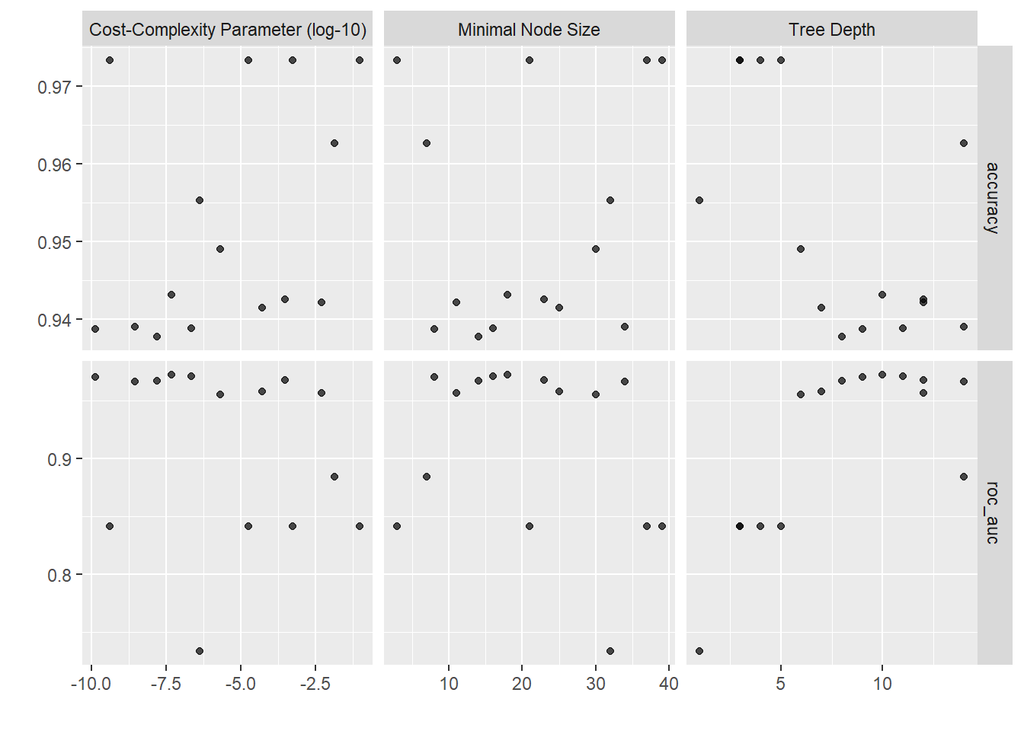

| cost_complexity | tree_depth | min_n | .metric | .estimator | mean | n | std_err | .config |
| --- | --- | --- | --- | --- | --- | --- | --- | --- |
| 0.0000000 | 4 | 21 | accuracy | binary | 0.9733625 | 5 | 0.0003620 | Preprocessor1_Model03 |
| 0.0942699 | 3 | 3 | accuracy | binary | 0.9733625 | 5 | 0.0003620 | Preprocessor1_Model05 |
| 0.0000177 | 3 | 37 | accuracy | binary | 0.9733625 | 5 | 0.0003620 | Preprocessor1_Model10 |
| 0.0005331 | 5 | 39 | accuracy | binary | 0.9733625 | 5 | 0.0003620 | Preprocessor1_Model13 |
| 0.0131751 | 14 | 7 | accuracy | binary | 0.9627000 | 5 | 0.0068627 | Preprocessor1_Model01 |

## Metryki na zbiorze testowym

| .metric | .estimator | .estimate | .config |
| --- | --- | --- | --- |
| accuracy | binary | 0.9702500 | Preprocessor1_Model1 |
| roc_auc | binary | 0.8297081 | Preprocessor1_Model1 |

## Wykres krzywej ROC

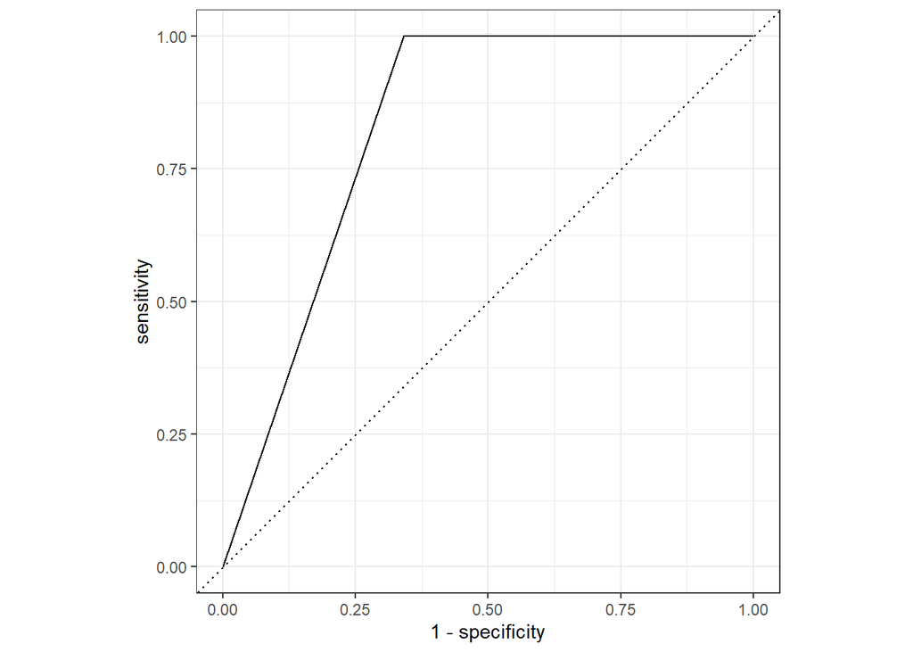

## Ostateczne Drzewo

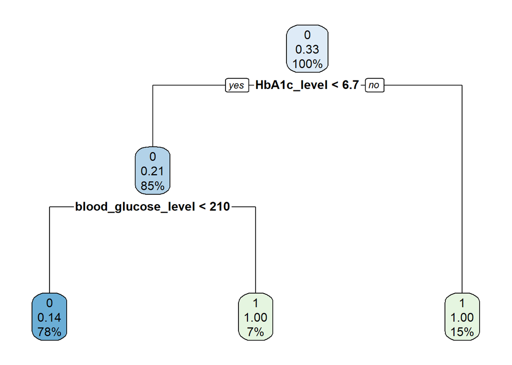

# Boosting

Model boosting przygotowaliśmy tuningując parametry ‘trees’, ‘min_n’, ‘tree_depth’ oraz używając silnika “xgboost”

## Predykcje na zbiorze uczącym

| id | .pred_class | .row | trees | min_n | tree_depth | .pred_0 | .pred_1 | diabetes | .config |
| --- | --- | --- | --- | --- | --- | --- | --- | --- | --- |
| Resample1 | 0 | 3 | 1575 | 4 | 10 | 0.9999933 | 0.0000067 | 0 | Preprocessor1_Model01 |
| Resample1 | 0 | 8 | 1575 | 4 | 10 | 0.9999958 | 0.0000042 | 0 | Preprocessor1_Model01 |
| Resample1 | 0 | 10 | 1575 | 4 | 10 | 0.9999896 | 0.0000104 | 0 | Preprocessor1_Model01 |
| Resample1 | 0 | 15 | 1575 | 4 | 10 | 0.9933129 | 0.0066871 | 0 | Preprocessor1_Model01 |
| Resample1 | 0 | 16 | 1575 | 4 | 10 | 0.9998524 | 0.0001476 | 0 | Preprocessor1_Model01 |
| Resample1 | 0 | 24 | 1575 | 4 | 10 | 0.9993985 | 0.0006015 | 0 | Preprocessor1_Model01 |

## Wykres i tabela najlepszych parametrów do tuningowania

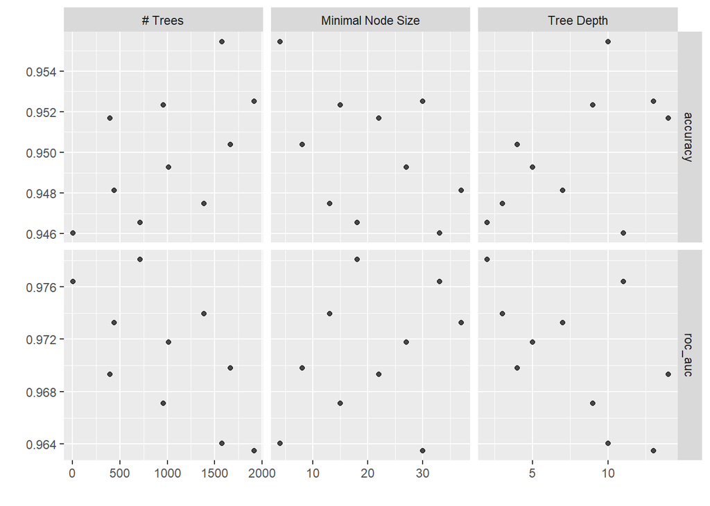

| trees | min_n | tree_depth | .metric | .estimator | mean | n | std_err | .config |
| --- | --- | --- | --- | --- | --- | --- | --- | --- |
| 1575 | 4 | 10 | accuracy | binary | 0.9554500 | 5 | 0.0006204 | Preprocessor1_Model01 |
| 1916 | 30 | 13 | accuracy | binary | 0.9525125 | 5 | 0.0007378 | Preprocessor1_Model08 |
| 957 | 15 | 9 | accuracy | binary | 0.9523375 | 5 | 0.0009043 | Preprocessor1_Model04 |
| 396 | 22 | 14 | accuracy | binary | 0.9516750 | 5 | 0.0007102 | Preprocessor1_Model06 |
| 1664 | 8 | 4 | accuracy | binary | 0.9504000 | 5 | 0.0008906 | Preprocessor1_Model02 |

## Metryki dla ostatecznego boostingu

| .metric | .estimator | .estimate | .config |
| --- | --- | --- | --- |
| accuracy | binary | 0.9443500 | Preprocessor1_Model1 |
| roc_auc | binary | 0.9778122 | Preprocessor1_Model1 |

## Wykres pola pod krzywą

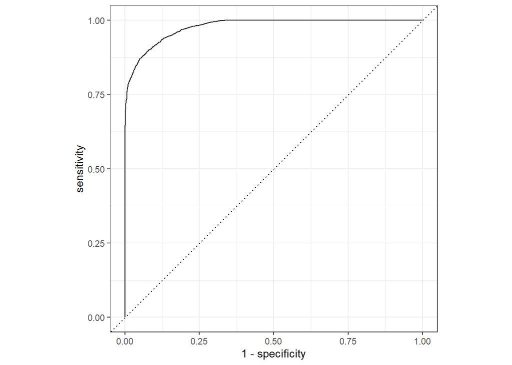

# Bagging

W modelu baggingu tunowaliśmy parametry ‘cost_complexity’, ‘tree_depth’ i ’ min_n’, a silnikiem był silnik “rpart”

## Predykcje na zbiorze uczącym

| id | .pred_class | .row | cost_complexity | tree_depth | min_n | .pred_0 | .pred_1 | diabetes | .config |
| --- | --- | --- | --- | --- | --- | --- | --- | --- | --- |
| Resample1 | 0 | 3 | 8.14e-05 | 5 | 19 | 0.8683513 | 0.1316487 | 0 | Preprocessor1_Model01 |
| Resample1 | 0 | 8 | 8.14e-05 | 5 | 19 | 0.8741486 | 0.1258514 | 0 | Preprocessor1_Model01 |
| Resample1 | 0 | 10 | 8.14e-05 | 5 | 19 | 0.8683513 | 0.1316487 | 0 | Preprocessor1_Model01 |
| Resample1 | 0 | 15 | 8.14e-05 | 5 | 19 | 0.8286136 | 0.1713864 | 0 | Preprocessor1_Model01 |
| Resample1 | 0 | 16 | 8.14e-05 | 5 | 19 | 0.8683513 | 0.1316487 | 0 | Preprocessor1_Model01 |
| Resample1 | 0 | 24 | 8.14e-05 | 5 | 19 | 0.8683513 | 0.1316487 | 0 | Preprocessor1_Model01 |

## Wykres i tabela najlepszych parametrów do tuningowania

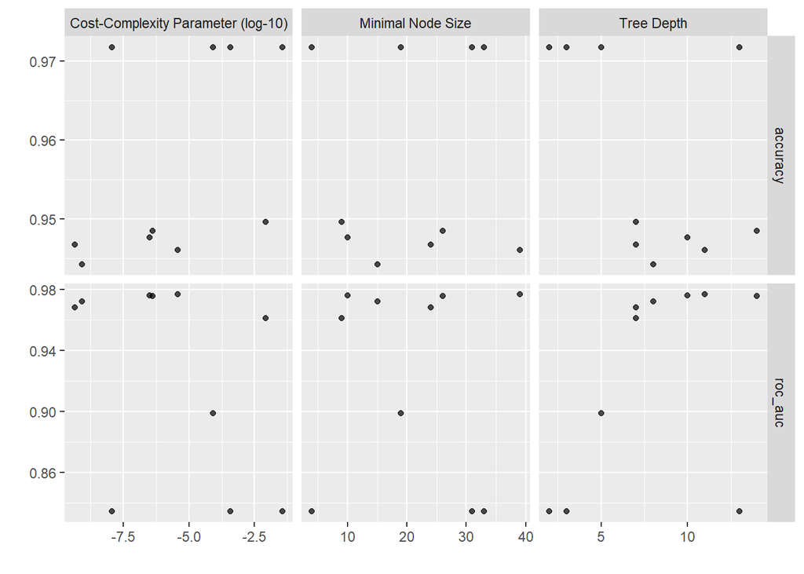

| cost_complexity | tree_depth | min_n | .metric | .estimator | mean | n | std_err | .config |
| --- | --- | --- | --- | --- | --- | --- | --- | --- |
| 0.0000814 | 5 | 19 | accuracy | binary | 0.9718 | 5 | 0.0004318 | Preprocessor1_Model01 |
| 0.0369073 | 13 | 4 | accuracy | binary | 0.9718 | 5 | 0.0004318 | Preprocessor1_Model02 |
| 0.0003802 | 3 | 31 | accuracy | binary | 0.9718 | 5 | 0.0004318 | Preprocessor1_Model03 |
| 0.0000000 | 2 | 33 | accuracy | binary | 0.9718 | 5 | 0.0004318 | Preprocessor1_Model09 |
| 0.0085319 | 7 | 9 | accuracy | binary | 0.9496 | 5 | 0.0018795 | Preprocessor1_Model05 |

## Metryki dla ostatecznego baggingu

| .metric | .estimator | .estimate | .config |
| --- | --- | --- | --- |
| accuracy | binary | 0.9464500 | Preprocessor1_Model1 |
| roc_auc | binary | 0.9755396 | Preprocessor1_Model1 |

## Wykres krzywej ROC

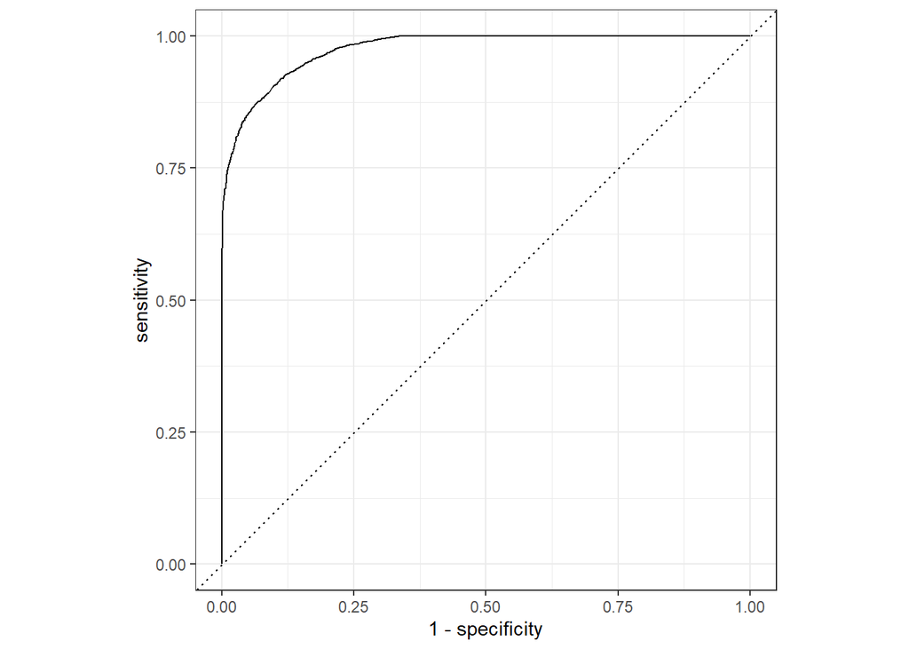

# Regresja logistyczna

W modelu regresji logistycznej tuningowaliśmy parametry ‘penalty’ i ‘mixture’ z silnikiem “glmnet”.

Do budowy siatki znów użyliśmy Łacińskiego hipersześcianu z 15 kombinacjami

| penalty | mixture |
| --- | --- |
| 0.0263446 | 0.5147017 |
| 0.0006342 | 0.4031823 |
| 0.0000046 | 0.2496484 |
| 0.0001012 | 0.7388552 |
| 0.0000000 | 0.0620459 |
| 0.0000004 | 0.8518774 |
| 0.0546149 | 0.3651667 |
| 0.0000108 | 0.9175365 |
| 0.0000000 | 0.1591863 |
| 0.0000496 | 0.4674055 |
| 0.0047921 | 0.6148634 |
| 0.4242866 | 0.7645563 |
| 0.0000001 | 0.2018939 |
| 0.0000000 | 0.9811917 |
| 0.0000000 | 0.6604124 |

## Predykcje na zbiorze uczącym

| id | .pred_class | .row | penalty | mixture | .pred_0 | .pred_1 | diabetes | .config |
| --- | --- | --- | --- | --- | --- | --- | --- | --- |
| Resample1 | 1 | 1 | 0 | 0.0620459 | 0.2334057 | 0.7665943 | 0 | Preprocessor1_Model01 |
| Resample1 | 0 | 3 | 0 | 0.0620459 | 0.9463177 | 0.0536823 | 0 | Preprocessor1_Model01 |
| Resample1 | 0 | 8 | 0 | 0.0620459 | 0.9794168 | 0.0205832 | 0 | Preprocessor1_Model01 |
| Resample1 | 0 | 9 | 0 | 0.0620459 | 0.9805709 | 0.0194291 | 0 | Preprocessor1_Model01 |
| Resample1 | 0 | 10 | 0 | 0.0620459 | 0.9979390 | 0.0020610 | 0 | Preprocessor1_Model01 |
| Resample1 | 0 | 15 | 0 | 0.0620459 | 0.7445419 | 0.2554581 | 0 | Preprocessor1_Model01 |

## Najlepsze parametry do tuningowania

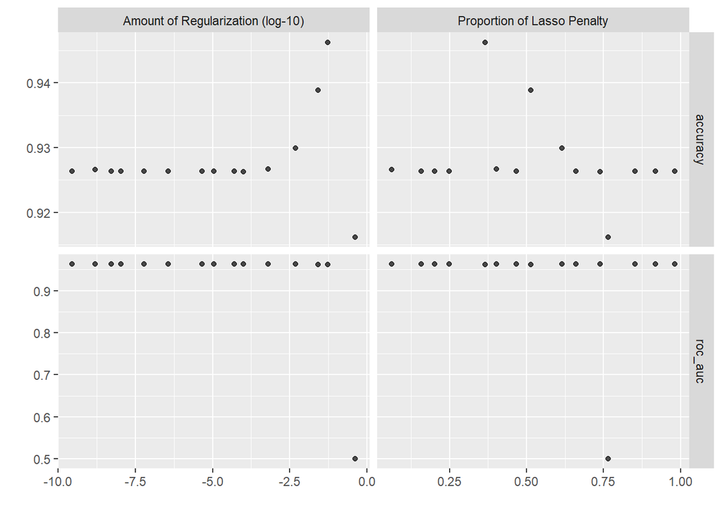

| penalty | mixture | .metric | .estimator | mean | n | std_err | .config |
| --- | --- | --- | --- | --- | --- | --- | --- |
| 0.0546149 | 0.3651667 | accuracy | binary | 0.9462750 | 5 | 0.0008069 | Preprocessor1_Model05 |
| 0.0263446 | 0.5147017 | accuracy | binary | 0.9388750 | 5 | 0.0010707 | Preprocessor1_Model08 |
| 0.0047921 | 0.6148634 | accuracy | binary | 0.9299500 | 5 | 0.0011508 | Preprocessor1_Model09 |
| 0.0006342 | 0.4031823 | accuracy | binary | 0.9267125 | 5 | 0.0011553 | Preprocessor1_Model06 |
| 0.0000000 | 0.0620459 | accuracy | binary | 0.9265875 | 5 | 0.0012094 | Preprocessor1_Model01 |

## Metryki dla ostatecznej regresji logistycznej

| .metric | .estimator | .estimate | .config |
| --- | --- | --- | --- |
| accuracy | binary | 0.9453000 | Preprocessor1_Model1 |
| roc_auc | binary | 0.9613407 | Preprocessor1_Model1 |

## Wykres krzywej ROC

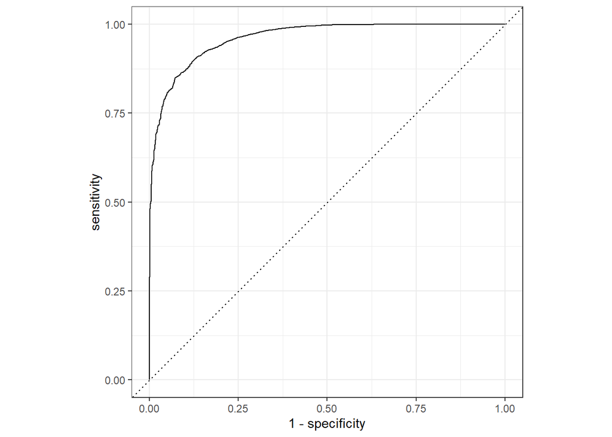

# Las losowy

Model lasu losowego zbudowaliśmy tuningując parametry ‘mtry’, ‘trees’ i ‘min_n’ z silnikiem “randomForest”, a jako siatkę użyliśmy siatki maksymalizującej entropię z 15 kombinacjami.

## Wykres i tabela najlepszych parametrów

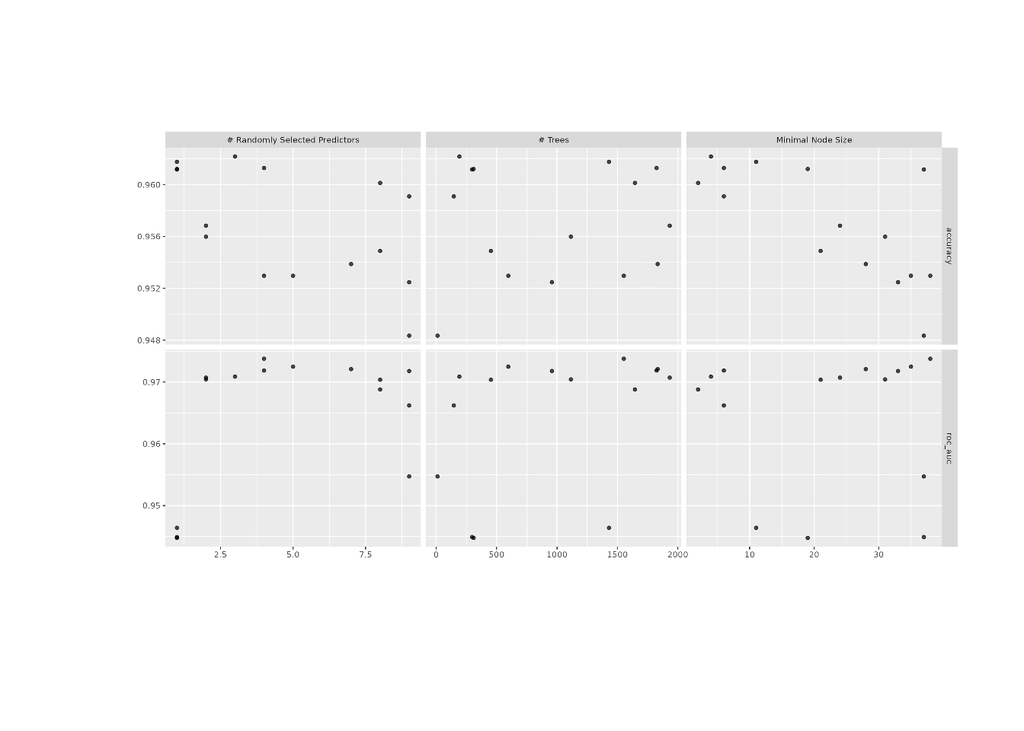

| X | mtry | trees | min_n | .metric | .estimator | mean | n | std_err | .config |
| --- | --- | --- | --- | --- | --- | --- | --- | --- | --- |
| 1 | 3 | 192 | 4 | accuracy | binary | 0.9621750 | 5 | 0.0005367 | Preprocessor1_Model13 |
| 2 | 1 | 1430 | 11 | accuracy | binary | 0.9617625 | 5 | 0.0006354 | Preprocessor1_Model12 |
| 3 | 4 | 1824 | 6 | accuracy | binary | 0.9612875 | 5 | 0.0004073 | Preprocessor1_Model15 |
| 4 | 1 | 310 | 19 | accuracy | binary | 0.9612125 | 5 | 0.0010322 | Preprocessor1_Model11 |
| 5 | 1 | 297 | 37 | accuracy | binary | 0.9611750 | 5 | 0.0005136 | Preprocessor1_Model06 |

## Metryki dla ostatecznego lasu

| .metric | .estimator | .estimate | .config |
| --- | --- | --- | --- |
| accuracy | binary | 0.9596500 | Preprocessor1_Model1 |
| roc_auc | binary | 0.9722377 | Preprocessor1_Model1 |

## Wykres krzywej ROC

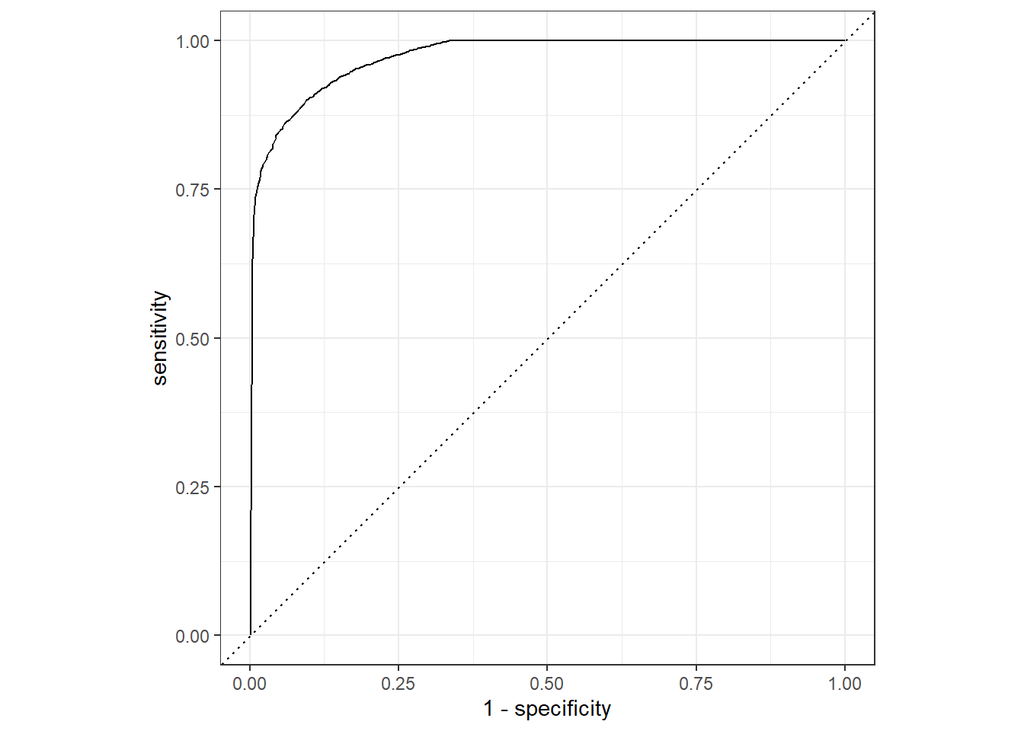

# Etapy uczenia sieci

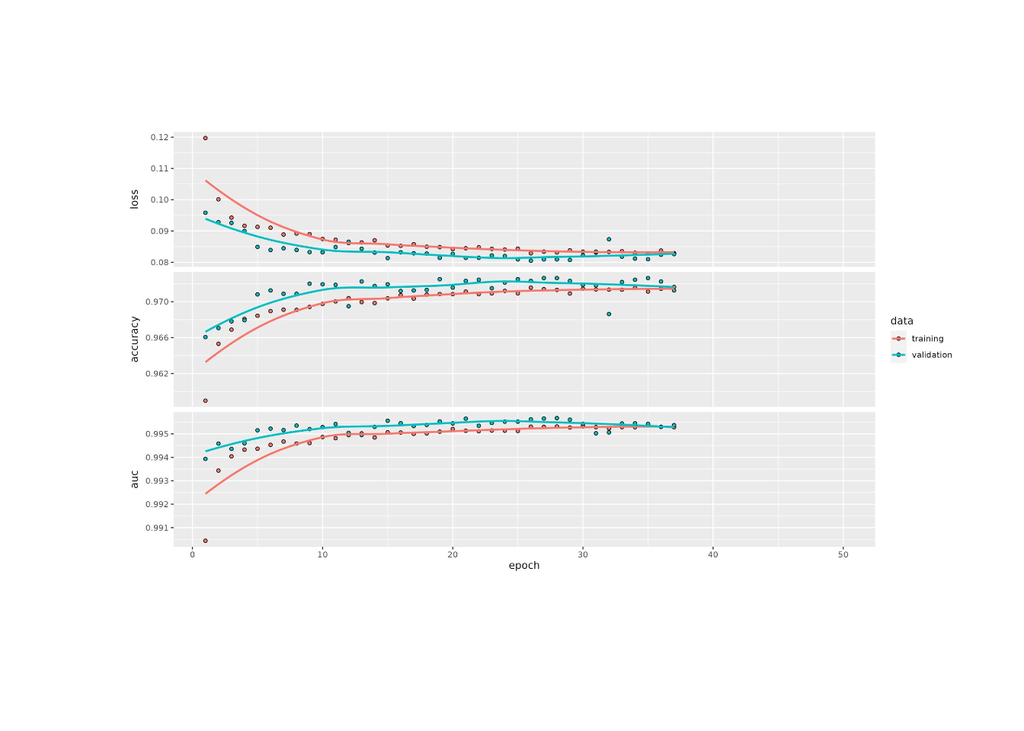

# Porównanie modeli

| Model | Accuracy | ROC AUC |
| --- | --- | --- |
| Drzewo | 0.97025 | 0.8297080709788208 |
| Boosting | 0.94435 | 0.9778121676435159 |
| Bagging | 0.94645 | 0.9755396206998531 |
| Logi_reg_acc | 0.9453 | 0.9613406971922439 |
| Las_losowy | 0.95965 | 0.9722377394269063 |
| Sieć_neuronowa | 0.9670000076293945 | 0.9937170147895813 |